# Modes of a Vibrating Building

In this notebook we will find the vibrational modes of a simple model of a building. We will assume that the mass of the floors are much more than the mass of the walls and that the lateral stiffness of the walls can be modeled by a simple linear spring. We will investigate how the building may vibrate under initial conditions that could be caused by a gust of wind and during ground vibration.

```python
from IPython.display import YouTubeVideo
```

```python
YouTubeVideo('g0cz-oDfUg0', width=600)
```

[video not shown]

```python
YouTubeVideo('hSwjkG3nv1c', width=600)
```

[video not shown]

```python
YouTubeVideo('kzVvd4Dk6sw', width=600)
```

[video not shown]

```python
import numpy as np
import matplotlib.pyplot as plt
from resonance.linear_systems import FourStoryBuildingSystem
```

This gives a bit nicer printing of large NumPy arrays.

```python
np.set_printoptions(precision=5, linewidth=100, suppress=True)
```

```python
%matplotlib inline
```

# Simulate the four story building

```python
sys = FourStoryBuildingSystem()
```

```python
sys.constants
```

```
{'k1': 5000,
 'k2': 5000,
 'k3': 5000,
 'k4': 5000,
 'm1': 4000,
 'm2': 4000,
 'm3': 4000,
 'm4': 4000}
```

```python
sys.coordinates
```

```
_CoordinatesDict([('x1', 0.001), ('x2', 0.01), ('x3', 0.02), ('x4', 0.025)])
```

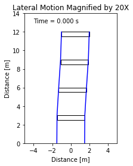

```python
sys.plot_configuration();
```

```python
traj = sys.free_response(30, sample_rate=10)
```

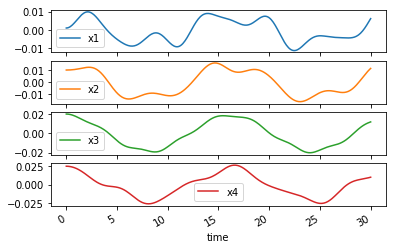

```python
traj[list(sys.coordinates.keys())].plot(subplots=True);
```

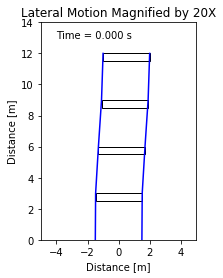

```python
sys.animate_configuration(fps=10)
```

```python
M, C, K = sys.canonical_coefficients()
```

```python
M
```

```
array([[4000,    0,    0,    0],
       [   0, 4000,    0,    0],
       [   0,    0, 4000,    0],
       [   0,    0,    0, 4000]])
```

```python
C
```

```
array([[ 0.,  0.,  0.,  0.],
       [ 0.,  0.,  0.,  0.],
       [ 0.,  0.,  0.,  0.],
       [ 0.,  0.,  0.,  0.]])
```

```python
K
```

```
array([[10000, -5000,     0,     0],
       [-5000, 10000, -5000,     0],
       [    0, -5000, 10000, -5000],
       [    0,     0, -5000,  5000]])
```

# Exercise

The system can be normalized by the mass matrix and transformed into a symmetric eigenvalue problem by introducing the new coordinate vector:

$$\mathbf{q}=\mathbf{L}^T\mathbf{x}$$

$\mathbf{L}$ is the Cholesky decomposition of the symmetric mass matrix, i.e. $\mathbf{M}=\mathbf{L}\mathbf{L}^T$.

The equation of motion becomes:

$$\ddot{\mathbf{q}} + \tilde{\mathbf{K}} \mathbf{q} = 0$$

Compute $\tilde{\mathbf{K}}$.

```python
L = np.linalg.cholesky(M)
L
```

```
array([[ 63.24555,   0.     ,   0.     ,   0.     ],
       [  0.     ,  63.24555,   0.     ,   0.     ],
       [  0.     ,   0.     ,  63.24555,   0.     ],
       [  0.     ,   0.     ,   0.     ,  63.24555]])
```

```python
M**0.5
```

```
array([[ 63.24555,   0.     ,   0.     ,   0.     ],
       [  0.     ,  63.24555,   0.     ,   0.     ],
       [  0.     ,   0.     ,  63.24555,   0.     ],
       [  0.     ,   0.     ,   0.     ,  63.24555]])
```

```python
import numpy.linalg as la
```

```python
from numpy.linalg import inv
```

```python
K_tilde = inv(L) @ K @ inv(L.T)
```

```python
K_tilde
```

```
array([[ 2.5 , -1.25,  0.  ,  0.  ],
       [-1.25,  2.5 , -1.25,  0.  ],
       [ 0.  , -1.25,  2.5 , -1.25],
       [ 0.  ,  0.  , -1.25,  1.25]])
```

Notice that $\tilde{\mathbf{K}}$ is symmetric, so we are guaranteed to get real eigenvalues and orthogonal eigenvectors when solving this system.

# Exercise

Find the eigenvalues and eigenvectors. Create the spectral matrix $\mathbf{\Lambda}$ and the matrix $P$ which contains the orthonormal eigenvectors of $\tilde{\mathbf{K}}$.

$$ \mathbf{P} = \left[ \mathbf{v}_1, \ldots, \mathbf{v}_4 \right] $$

```python
evals, evecs = np.linalg.eig(K_tilde)
evals
```

```
array([ 4.41511,  2.93412,  1.25   ,  0.15077])
```

```python
evecs
```

```
array([[ 0.42853,  0.65654, -0.57735,  0.22801],
       [-0.65654, -0.22801, -0.57735,  0.42853],
       [ 0.57735, -0.57735, -0.     ,  0.57735],
       [-0.22801,  0.42853,  0.57735,  0.65654]])
```

```python
Lambda = np.diag(evals)
Lambda
```

```
array([[ 4.41511,  0.     ,  0.     ,  0.     ],
       [ 0.     ,  2.93412,  0.     ,  0.     ],
       [ 0.     ,  0.     ,  1.25   ,  0.     ],
       [ 0.     ,  0.     ,  0.     ,  0.15077]])
```

```python
P = evecs
```

# Exercise

Prove that the eigenvectors in $\mathbf{P}$ are orthonormal.

```python
np.dot(P[:, 0], P[:, 1])
```

```
-2.7755575615628914e-16
```

```python
np.linalg.norm(P[:, 0])
```

```
1.0
```

```python
P[:, 0].T @ P[:, 1]
```

```
-2.7755575615628914e-16
```

```python
P[:, 0].T @ P[:, 0]
```

```
1.0
```

An orthonormal matrix has the property that its transpose multiplied by itself is the identity matrix.

```python
P.T @ P
```

```
array([[ 1., -0.,  0., -0.],
       [-0.,  1.,  0.,  0.],
       [ 0.,  0.,  1., -0.],
       [-0.,  0., -0.,  1.]])
```

# Exercise

Find the natural freqencies of the system in both radians per second and Hertz, store them in an array in the order of the eigenvalues with names `ws` and `fs`.

```python
ws = np.sqrt(evals)
ws
```

```
array([ 2.10122,  1.71293,  1.11803,  0.38829])
```

```python
fs = ws / 2 / np.pi
fs
```

```
array([ 0.33442,  0.27262,  0.17794,  0.0618 ])
```

# Exercise

Transform the eigenvectors back into the coordinate system associated with $\mathbf{x}$.

$$ \mathbf{S} = \left[ \mathbf{u}_1, \ldots, \mathbf{u}_4 \right] $$

```python
S = np.linalg.inv(L.T) @ P
S
```

```
array([[ 0.00678,  0.01038, -0.00913,  0.00361],
       [-0.01038, -0.00361, -0.00913,  0.00678],
       [ 0.00913, -0.00913, -0.     ,  0.00913],
       [-0.00361,  0.00678,  0.00913,  0.01038]])
```

```python
sys.coordinates
```

```
_CoordinatesDict([('x1', 0.001), ('x2', 0.01), ('x3', 0.02), ('x4', 0.025)])
```

# Exercise: visualize the modeshapes

The eigenmodes (mode shapes) are contained in each column of $\mathbf{S}$. Create a plot for each mode shape with these specifications:

- The title of each plot should be the frequency of the corresponding modeshape in Hz.
- The y axis should be made up of the values [0, 3, 6, 9, 12] meters.
- The x axis should plot the five values. The first should be zero and the remaining values should be the components of the mode shape in order of the component associated with the lowest floor to the highest.
- Plot lines with small circles at each data point.

```python
S[:, 0]
```

```
array([ 0.00678, -0.01038,  0.00913, -0.00361])
```

```python
np.hstack((0, S[:, 0]))
```

```
array([ 0.     ,  0.00678, -0.01038,  0.00913, -0.00361])
```

```python
u1 = S[:, 0]
u1
```

```
array([ 0.00678, -0.01038,  0.00913, -0.00361])
```

```python
u1[::-1]
```

```
array([-0.00361,  0.00913, -0.01038,  0.00678])
```

```python
S[:, 2]
```

```
array([-0.00913, -0.00913, -0.     ,  0.00913])
```

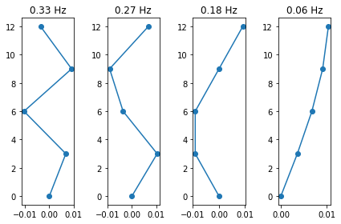

```python
fig, axes = plt.subplots(1, 4)

for i in range(4):
    axes[i].plot(np.hstack((0, S[:, i])), [0, 3, 6, 9, 12], marker='o')
    axes[i].set_title('{:1.2f} Hz'.format(fs[i]))

plt.tight_layout()
```

```python
fs[0]
```

```
0.33441900490046539
```

```python
S[:, 0]
```

```
array([ 0.00678, -0.01038,  0.00913, -0.00361])
```

```python
sys.coordinates['x1'] = S[0, 2]
sys.coordinates['x2'] = S[1, 2]
sys.coordinates['x3'] = S[2, 2]
sys.coordinates['x4'] = S[3, 2]
```

```python
traj = sys.free_response(30, sample_rate=10)
```

[output not shown]

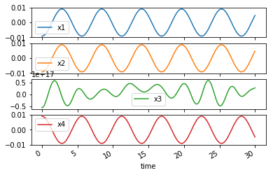

```python
traj[list(sys.coordinates.keys())].plot(subplots=True)
```

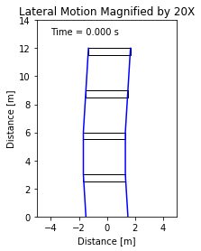

```python
sys.animate_configuration(fps=10)
```

# Simulating the trajectory

The trajectory of building's coordinates can be found with:

$$ \mathbf{x}(t) = \sum_{i=1}^n c_i \sin(\omega_i t + \phi_i) \mathbf{u}_i $$

where

$$ \phi_i = \arctan \frac{\omega_i \mathbf{v}_i^T \mathbf{q}_0}{\mathbf{v}_i^T \dot{\mathbf{q}}_0} $$

and

$$ c_i = \frac{\mathbf{v}^T_i \mathbf{q}_0}{\sin\phi_i} $$

$c_i$ are the modal participation factors and reflect what proportion of each mode is excited given specific initial conditions. If the initial conditions are the eigenmode, $\mathbf{u}_i$, the all but the $i$th $c_i$ will be zero.

# Exercise

Show that if $\mathbf{q}_0 = \mathbf{v}_i$ then $c_i = 1$ all other modal participation factors are 0. Also, report all of the phase angles, $\phi_i$, in degrees.

```python
for i in range(4):
    x0 = S[:, i]
    xd0 = np.zeros(4)
    print(x0)

    q0 = L.T @ x0
    qd0 = L.T @ xd0

    phis = np.arctan2(ws * P.T @ q0, P.T @ xd0)
    print(np.rad2deg(phis))

    cs = P.T @ q0 / np.sin(phis)
    print(cs)
    print('=' * 40)
```

```
[ 0.00678 -0.01038  0.00913 -0.00361]
[ 90.  90.  90.  90.]
[ 1. -0.  0. -0.]
========================================
[ 0.01038 -0.00361 -0.00913  0.00678]
[ 90.  90. -90. -90.]
[-0.  1. -0. -0.]
========================================
[-0.00913 -0.00913 -0.       0.00913]
[ 90. -90.  90. -90.]
[ 0. -0.  1.  0.]
========================================
[ 0.00361  0.00678  0.00913  0.01038]
[ 90. -90. -90.  90.]
[-0. -0.  0.  1.]
========================================
```

# Exercise

Create a function called `simulate()` that returns the trajectories of the coordinates given an array of monotonically increasing time values and the initial conditions of the system.

It should look like:

```
def simulate(t, x0, xd0):
    """Returns the state trajectory.

    Parameters
    ==========
    t : ndarray, shape(m,)
        Monotonic values of time.
    x0 : ndarray, shape(n,)
        The initial conditions of each coordinate.
    xd0 : ndarray, shape(n,)
        The initial conditions of each speed.

    Returns
    =======
    x : ndarray, shape(m, n)
        The trajectories of each state.

    """

    # your code here

    return x
```

```python
def simulate(t, x0, xd0):

    q0 = L.T @ x0
    qd0 = L.T @ xd0
    phis = np.arctan2(ws * P.T @ q0, P.T @ xd0)
    cs = P.T @ q0 / np.sin(phis)

    x = np.zeros((len(x0), len(t)))
    for ci, wi, phii, ui in zip(cs, ws, phis, S.T):
        x += ci * np.sin(wi * t + phii) * np.tile(ui, (len(t), 1)).T

    return x
```

# Exercise

Using the plotting function below, show that the results found here are the same as the simulations from the `FourStoryBuildingSystem` given the same initial conditions.

```python
def plot_trajectories(t, x):

    fig, axes = plt.subplots(4, 1)

    for i, ax in enumerate(axes.flatten()):
        ax.plot(t, x[i])
        ax.set_ylabel(r'$x_{}$ [m]'.format(i + 1))
    ax.set_xlabel('Time [s]')

    plt.tight_layout()
```

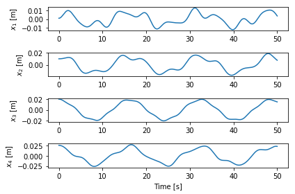

```python
t = np.linspace(0, 50, num=50 * 60)
x0 = np.array([0.001, 0.010, 0.020, 0.025])
xd0 = np.zeros(4)
x = simulate(t, x0, xd0)
plot_trajectories(t, x)
```

This shows the plot of a single mode:

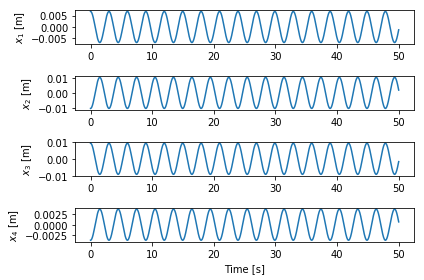

```python
x = simulate(t, S[:, 0], np.zeros(4))
plot_trajectories(t, x)
```